# Project Supervised Learning.

#### Age distribution of Loan Holders, and Non Loan Holders is same

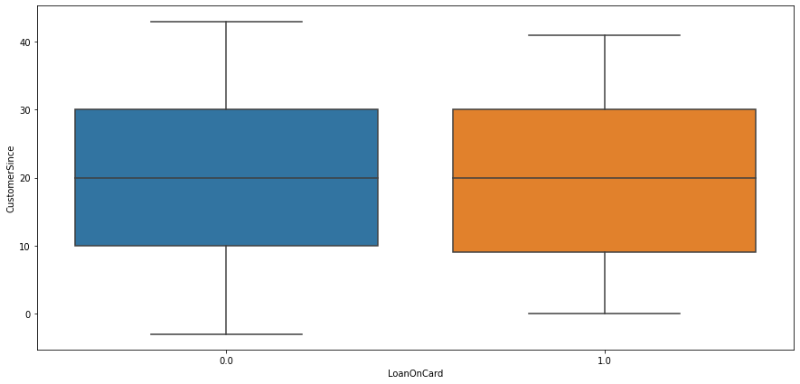

```python
#LoanOnCard vs CustomerSince

plt.figure(figsize=(15,7))
sns.boxplot(x='LoanOnCard', y='CustomerSince', data= df)
plt.show()
```

#### CustomerSince variable is equal for Load Holders, and Non Loan Holders.

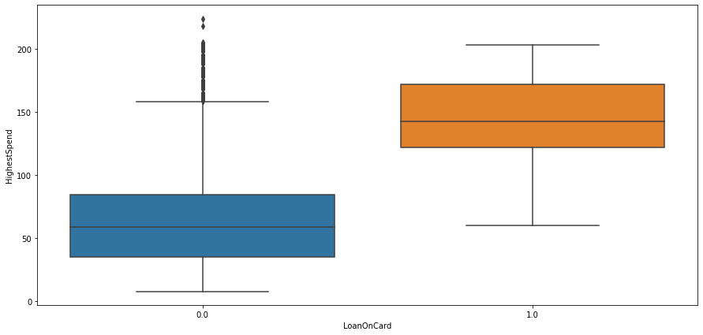

```python
#HighestSpend vs LoanOnCard

plt.figure(figsize=(15,7))
sns.boxplot(x='LoanOnCard', y='HighestSpend', data= df)
plt.show()
```

#### People having loan on card spend more than who doesn't have. There are some exceptions.

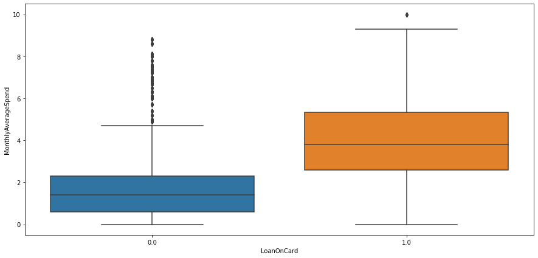

```python
#MonthlyAverageSpend vs LoanOnCard


plt.figure(figsize=(15,7))
sns.boxplot(x='LoanOnCard', y='MonthlyAverageSpend', data= df)
plt.show()
```

#### Monthly average is more for Loan Holders

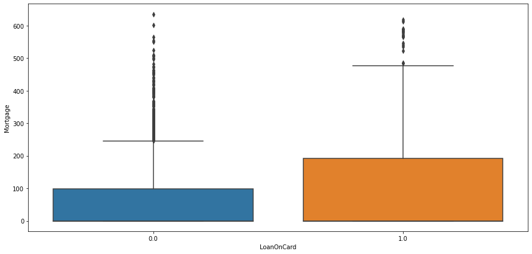

```python
#Mortgage vs LoanOnCard

plt.figure(figsize=(15,7))
sns.boxplot(x='LoanOnCard', y='Mortgage', data= df)
plt.show()
```

#### Mortage value is high for loan holders. Outliers on both 1, and 0.

#### Age of LoanHolders and Non Loan Holders is almost equal

### We can see correlation bewteen Continuous variables

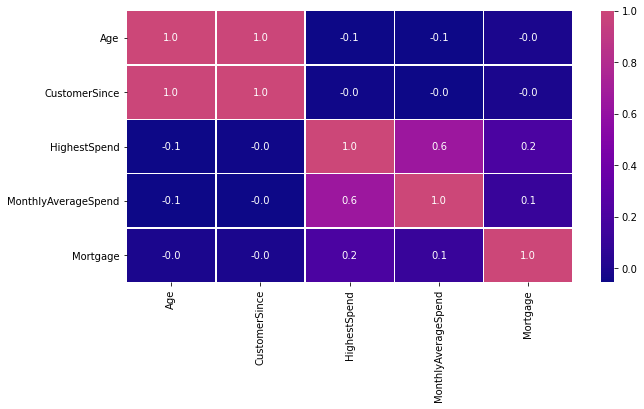

```python
plt.figure(figsize=(10,5))
sns.heatmap(df.corr(), annot=True, linewidths=.5, fmt= '.1f', center = 1, cmap='plasma' )
plt.show()
```

#### Correlation can be seen between -

#### (Age, and Customer Since),

#### (Highest Spend, and Monthly Average spend)

### Inter Category bi variate analysis

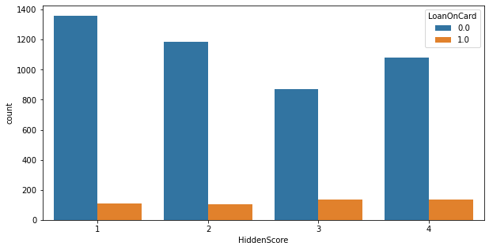

```python
plt.figure(figsize=(10,5))
sns.countplot(df['HiddenScore'],hue=df['LoanOnCard'])
```

#### Hidden Score is higher with people with Loan on Card

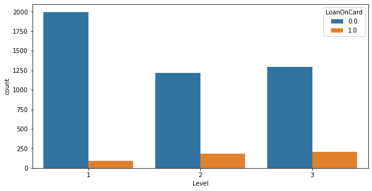

```python
plt.figure(figsize=(10,5))
sns.countplot(df['Level'],hue=df['LoanOnCard'])
```

#### Level 1 has maximum number of people wihout any Loan. 2, and 3 is similar.

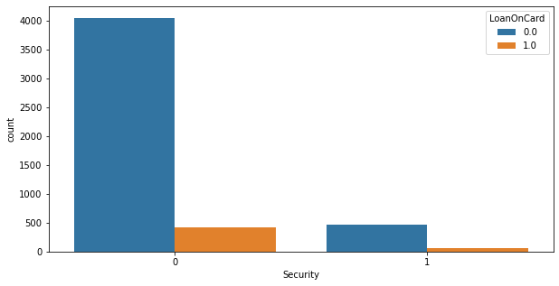

```python
plt.figure(figsize=(10,5))
sns.countplot(df['Security'],hue=df['LoanOnCard'])
```

#### There are more customers who have loan does not have any security.

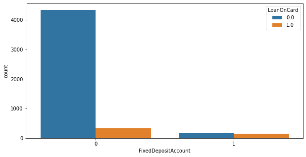

```python
plt.figure(figsize=(10,5))
sns.countplot(df['FixedDepositAccount'],hue=df['LoanOnCard'])
```

#### There are more Loan holders without Fixed Deposit Accounts.

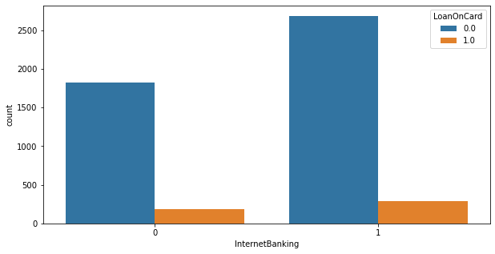

```python
plt.figure(figsize=(10,5))
sns.countplot(df['InternetBanking'],hue=df['LoanOnCard'])
```

#### There are more Loan holders that are Internet Banking users.

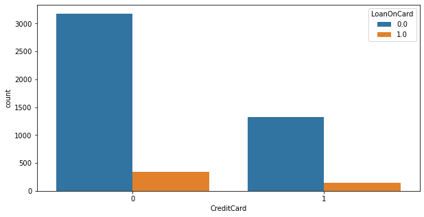

```python
plt.figure(figsize=(10,5))
sns.countplot(df['CreditCard'],hue=df['LoanOnCard'])
```

## Multivariate Analysis

### We will use categorical columns, and see their affect on monthly average spend and Loan hold.

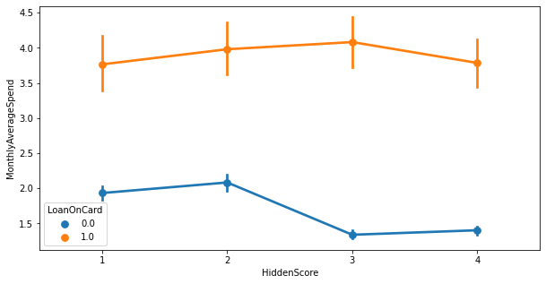

```python
plt.figure(figsize=(10,5))
sns.pointplot(x="HiddenScore", y="MonthlyAverageSpend", hue = 'LoanOnCard',  data=df)
plt.show()
```

#### People with Loan on Card spend more money. Highest spent is for people with HIdden score 3.

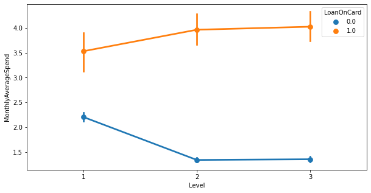

```python
plt.figure(figsize=(10,5))
sns.pointplot(x='Level', y="MonthlyAverageSpend", hue = 'LoanOnCard',  data=df)
plt.show()
```

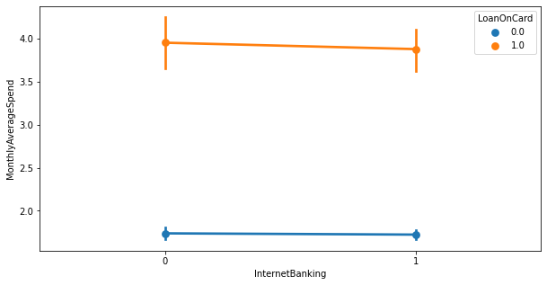

```python
plt.figure(figsize=(10,5))
sns.pointplot(x="InternetBanking", y="MonthlyAverageSpend", hue = 'LoanOnCard',  data=df)
plt.show()
```

#### people with Loan spend more money on average, but no affect of internet Banking.

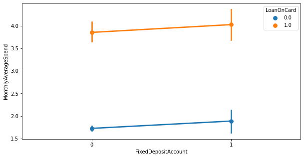

```python
plt.figure(figsize=(10,5))
sns.pointplot(x="FixedDepositAccount", y="MonthlyAverageSpend", hue = 'LoanOnCard',  data=df)
plt.show()
```

#### People with Loan spends more. People with Loan, and Fixed Deposit Account spends the most.

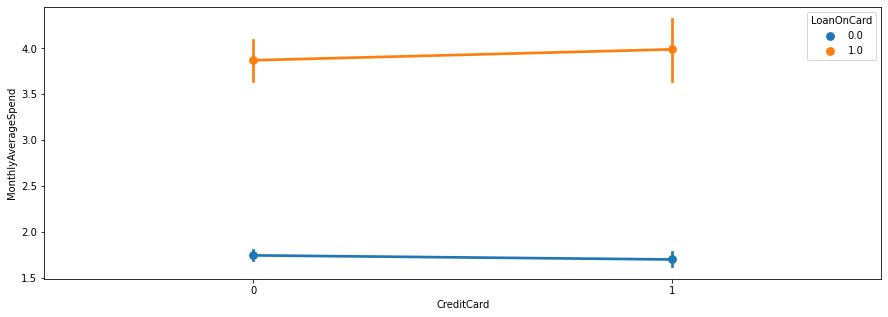

```python
plt.figure(figsize=(15,5))
sns.pointplot(x="CreditCard", y="MonthlyAverageSpend", hue = 'LoanOnCard',  data=df)
plt.show()
```

```python
X=df.drop(columns='LoanOnCard')
y=df['LoanOnCard']
```

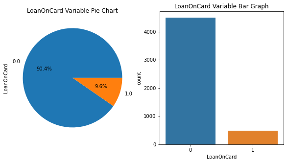

```python
f,axes=plt.subplots(1,2,figsize=(10,5))
df['LoanOnCard'].value_counts().plot.pie(autopct='%1.1f%%',ax=axes[0])
sns.countplot('LoanOnCard',data=df,ax=axes[1],order=[0,1])
axes[0].set_title('LoanOnCard Variable Pie Chart')
axes[1].set_title('LoanOnCard Variable Bar Graph')
plt.show()
```

## Performing Train test split and model builfing on imbalanced Data.

```python
X_train, X_test, y_train, y_test = train_test_split(X, y, test_size=0.30, random_state=10)
```

```python
logit = LogisticRegression()
logit.fit(X_train, y_train)
logit_pred = logit.predict(X_test)

print('Accuracy on Training data:',logit.score(X_train, y_train) )
print('Accuracy on Test data:',logit.score(X_test, y_test) )
```

```
Accuracy on Training data: 0.9492254733218589
Accuracy on Test data: 0.9544846050870147
```

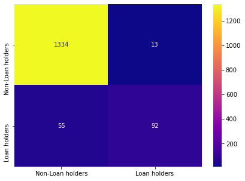

```python
cm = confusion_matrix(y_test, logit_pred, labels=[0, 1])

df_cm = pd.DataFrame(cm, index = [i for i in ["Non-Loan holders","Loan holders"]],
                  columns = [i for i in ["Non-Loan holders","Loan holders"]])
plt.figure(figsize = (7,5))
sns.heatmap(df_cm, annot=True ,fmt='g', cmap='plasma')
plt.show()
```

```python
print("classification  Matrix:\n",classification_report(y_test,logit_pred))
```

```
classification  Matrix:
               precision    recall  f1-score   support

         0.0       0.96      0.99      0.98      1347
         1.0       0.88      0.63      0.73       147

    accuracy                           0.95      1494
   macro avg       0.92      0.81      0.85      1494
weighted avg       0.95      0.95      0.95      1494
```

#### We can see that the model is good when predicting class 0, with precision, recall and f1 score of 96,99,and 98 respectively

#### The model is predicts Class 1 with precision, recall, and f1 score of 88,63, and 73 respectively.

#### We can see a significant fall in Recall in the Class 1 prediction.

## Lets try building Logistic regression model with balanced Class weight

```python
logit = LogisticRegression(class_weight='balanced')
logit.fit(X_train, y_train)
logit_pred = logit.predict(X_test)

print('Accuracy on Training data:',logit.score(X_train, y_train) )
print('Accuracy on Test data:',logit.score(X_test, y_test) )
```

```
Accuracy on Training data: 0.8950086058519794
Accuracy on Test data: 0.8728246318607764
```

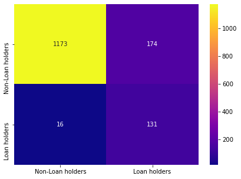

```python
cm = confusion_matrix(y_test, logit_pred, labels=[0, 1])

df_cm = pd.DataFrame(cm, index = [i for i in ["Non-Loan holders","Loan holders"]],
                  columns = [i for i in ["Non-Loan holders","Loan holders"]])
plt.figure(figsize = (7,5))
sns.heatmap(df_cm, annot=True ,fmt='g', cmap='plasma')
plt.show()
```

```python
print("classification  Matrix:\n",classification_report(y_test,logit_pred))
```

```
classification  Matrix:
               precision    recall  f1-score   support

         0.0       0.99      0.87      0.93      1347
         1.0       0.43      0.89      0.58       147

    accuracy                           0.87      1494
   macro avg       0.71      0.88      0.75      1494
weighted avg       0.93      0.87      0.89      1494
```

#### With balanced Class Weight, we have increased the Recall value, but Precision and f1 score is adversely affected.

```python
logit = LogisticRegression(class_weight='{0: 0.4, 1: 0.6}')
logit.fit(X_train, y_train)
logit_pred = logit.predict(X_test)

print('Accuracy on Training data:',logit.score(X_train, y_train) )
print('Accuracy on Test data:',logit.score(X_test, y_test) )
```

```
Accuracy on Training data: 0.9492254733218589
Accuracy on Test data: 0.9544846050870147
```

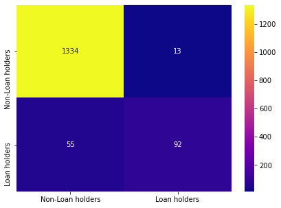

```python
cm = confusion_matrix(y_test, logit_pred, labels=[0, 1])

df_cm = pd.DataFrame(cm, index = [i for i in ["Non-Loan holders","Loan holders"]],
                  columns = [i for i in ["Non-Loan holders","Loan holders"]])
plt.figure(figsize = (7,5))
sns.heatmap(df_cm, annot=True ,fmt='g', cmap='plasma')
plt.show()
```

```python
print("classification  Matrix:\n",classification_report(y_test,logit_pred))
```

```
classification  Matrix:
               precision    recall  f1-score   support

         0.0       0.96      0.99      0.98      1347
         1.0       0.88      0.63      0.73       147

    accuracy                           0.95      1494
   macro avg       0.92      0.81      0.85      1494
weighted avg       0.95      0.95      0.95      1494
```

#### Trying different values for class weight is not giving us a positive output.

## Building Naive Bayes Classifier

```python
from sklearn.naive_bayes import GaussianNB
g_model = GaussianNB()
g_model.fit(X_train, y_train)
g_pred = g_model.predict(X_test)

print('Accuracy on Training data:',g_model.score(X_train, y_train) )
print('Accuracy on Test data:',g_model.score(X_test, y_test) )
```

```
Accuracy on Training data: 0.8861158921399885
Accuracy on Test data: 0.8761713520749665
```

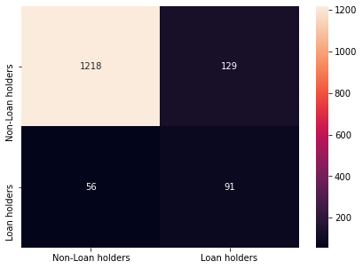

```python
cm = confusion_matrix(y_test, g_pred, labels=[0, 1])

df_cm = pd.DataFrame(cm, index = [i for i in ["Non-Loan holders","Loan holders"]],
                  columns = [i for i in ["Non-Loan holders","Loan holders"]])
plt.figure(figsize = (7,5))
sns.heatmap(df_cm, annot=True ,fmt='g')
plt.show()
```

```python
print("classification  Matrix:\n",classification_report(y_test,g_pred))
```

```
classification  Matrix:
               precision    recall  f1-score   support

         0.0       0.96      0.90      0.93      1347
         1.0       0.41      0.62      0.50       147

    accuracy                           0.88      1494
   macro avg       0.68      0.76      0.71      1494
weighted avg       0.90      0.88      0.89      1494
```

#### We can see that the Naive Bayes shows fluctuating results, and performs poorly while predicting the Class 1. This should not be used.

# CONCLUSION and SUGGESTIONS:

#### The Logistic Regression model returns the best results. And that should be used.

#### Logistic Regression model without balancing also returned satisfactory results.

#### We saw some difference for predicting Class 1 and 0, but it was the best among the other models.

#### Balancing the data with Class Weight, improved Recall value but it adversely affected Precision and Accuracy.

#### It is suggested that units of features should be clear. As they were masked in this case.

#### It would be better if the data is balanced, as the target data was hugely imbalanced with 90:10 ratio.

#### Quantity of the data was good, it helped as dropping some data did not cause significant loss of information.